# Human Activity Recognition with Machine Learning

Dave Friedman

Saturday, October 25, 2014

# Introduction & Summary

Is it possible to quantify how well an activity is performed? In their paper, *Qualitative Activity Recognition of Weight Lifting Exercises*, Velloso, Bulling, Gellersen, Ugulino, & Fuks <sup>1</sup> investigate. The researchers had 6 participants curl a 1.25kg dumbbell in 5 different fashions, each according to a specification: Class A (perfect form), Class B (throwing elbows out to front), class C (raising the dumbbell halfway), Class D (lowering the dumbbell halfway), and class E (throwing the hips to the front). Each participant performed 10 repetitions for each class of dumbbell curl. Velleso et. al. found that the quality of dumbbell curls could be quantified, through manual feature selection and statistical analysis.

In this project, created for the [Practical Machine Learning course](https://www.coursera.org/course/predmachlearn) (offered by Johns Hopkins University, via Coursera’s platform), we’ll investigate whether or not their manual feature selection could be replicated naively, with Stochastic Gradient Boosting.

<sup>1</sup>: Velloso, E.; Bulling, A.; Gellersen, H.; Ugulino, W.; Fuks, H. Qualitative Activity Recognition of Weight Lifting Exercises. Proceedings of 4th International Conference in Cooperation with SIGCHI (Augmented Human ’13) . Stuttgart, Germany: ACM SIGCHI, 2013.

## Get the Data

```r
trainURL <- "https://d396qusza40orc.cloudfront.net/predmachlearn/pml-training.csv"
testURL  <- "https://d396qusza40orc.cloudfront.net/predmachlearn/pml-testing.csv"

download.file(testURL, "pml-testing.csv", method="curl")
download.file(trainURL, "pml-training.csv", method="curl")

problem.set <- read.csv("pml-testing.csv")
df <- read.csv("pml-training.csv")
```

## Explore the Data

```r
str(df)
```

```
## 'data.frame':    19622 obs. of  160 variables:
##  $ X                       : int  1 2 3 4 5 6 7 8 9 10 ...
##  $ user_name               : Factor w/ 6 levels "adelmo","carlitos",..: 2 2 2 2 2 2 2 2 2 2 ...
##  $ raw_timestamp_part_1    : int  1323084231 1323084231 1323084231 1323084232 1323084232 1323084232 1323084232 1323084232 1323084232 1323084232 ...
##  $ raw_timestamp_part_2    : int  788290 808298 820366 120339 196328 304277 368296 440390 484323 484434 ...
##  $ cvtd_timestamp          : Factor w/ 20 levels "02/12/2011 13:32",..: 9 9 9 9 9 9 9 9 9 9 ...
##  $ new_window              : Factor w/ 2 levels "no","yes": 1 1 1 1 1 1 1 1 1 1 ...
##  $ num_window              : int  11 11 11 12 12 12 12 12 12 12 ...
##  $ roll_belt               : num  1.41 1.41 1.42 1.48 1.48 1.45 1.42 1.42 1.43 1.45 ...
##  $ pitch_belt              : num  8.07 8.07 8.07 8.05 8.07 8.06 8.09 8.13 8.16 8.17 ...
##  $ yaw_belt                : num  -94.4 -94.4 -94.4 -94.4 -94.4 -94.4 -94.4 -94.4 -94.4 -94.4 ...
##  $ total_accel_belt        : int  3 3 3 3 3 3 3 3 3 3 ...
##  $ kurtosis_roll_belt      : Factor w/ 397 levels "","-0.016850",..: 1 1 1 1 1 1 1 1 1 1 ...
##  $ kurtosis_picth_belt     : Factor w/ 317 levels "","-0.021887",..: 1 1 1 1 1 1 1 1 1 1 ...
##  $ kurtosis_yaw_belt       : Factor w/ 2 levels "","#DIV/0!": 1 1 1 1 1 1 1 1 1 1 ...
```

[output cut: 86 more lines]

```r
head(df[1:5], 25)
```

```
##     X user_name raw_timestamp_part_1 raw_timestamp_part_2   cvtd_timestamp
## 1   1  carlitos           1323084231               788290 05/12/2011 11:23
## 2   2  carlitos           1323084231               808298 05/12/2011 11:23
## 3   3  carlitos           1323084231               820366 05/12/2011 11:23
## 4   4  carlitos           1323084232               120339 05/12/2011 11:23
## 5   5  carlitos           1323084232               196328 05/12/2011 11:23
## 6   6  carlitos           1323084232               304277 05/12/2011 11:23
## 7   7  carlitos           1323084232               368296 05/12/2011 11:23
## 8   8  carlitos           1323084232               440390 05/12/2011 11:23
## 9   9  carlitos           1323084232               484323 05/12/2011 11:23
## 10 10  carlitos           1323084232               484434 05/12/2011 11:23
## 11 11  carlitos           1323084232               500302 05/12/2011 11:23
## 12 12  carlitos           1323084232               528316 05/12/2011 11:23
## 13 13  carlitos           1323084232               560359 05/12/2011 11:23
## 14 14  carlitos           1323084232               576390 05/12/2011 11:23
## 15 15  carlitos           1323084232               604281 05/12/2011 11:23
## 16 16  carlitos           1323084232               644302 05/12/2011 11:23
## 17 17  carlitos           1323084232               692324 05/12/2011 11:23
## 18 18  carlitos           1323084232               732306 05/12/2011 11:23
## 19 19  carlitos           1323084232               740353 05/12/2011 11:23
## 20 20  carlitos           1323084232               788335 05/12/2011 11:23
## 21 21  carlitos           1323084232               876301 05/12/2011 11:23
## 22 22  carlitos           1323084232               892313 05/12/2011 11:23
## 23 23  carlitos           1323084232               932285 05/12/2011 11:23
## 24 24  carlitos           1323084232               996313 05/12/2011 11:23
## 25 25  carlitos           1323084233                28311 05/12/2011 11:23
```

```r
head(df[5:10], 25)
```

```
##      cvtd_timestamp new_window num_window roll_belt pitch_belt yaw_belt
## 1  05/12/2011 11:23         no         11      1.41       8.07    -94.4
## 2  05/12/2011 11:23         no         11      1.41       8.07    -94.4
## 3  05/12/2011 11:23         no         11      1.42       8.07    -94.4
## 4  05/12/2011 11:23         no         12      1.48       8.05    -94.4
## 5  05/12/2011 11:23         no         12      1.48       8.07    -94.4
## 6  05/12/2011 11:23         no         12      1.45       8.06    -94.4
## 7  05/12/2011 11:23         no         12      1.42       8.09    -94.4
## 8  05/12/2011 11:23         no         12      1.42       8.13    -94.4
## 9  05/12/2011 11:23         no         12      1.43       8.16    -94.4
## 10 05/12/2011 11:23         no         12      1.45       8.17    -94.4
## 11 05/12/2011 11:23         no         12      1.45       8.18    -94.4
## 12 05/12/2011 11:23         no         12      1.43       8.18    -94.4
## 13 05/12/2011 11:23         no         12      1.42       8.20    -94.4
## 14 05/12/2011 11:23         no         12      1.42       8.21    -94.4
## 15 05/12/2011 11:23         no         12      1.45       8.20    -94.4
## 16 05/12/2011 11:23         no         12      1.48       8.15    -94.4
## 17 05/12/2011 11:23         no         12      1.51       8.12    -94.4
## 18 05/12/2011 11:23         no         12      1.55       8.08    -94.4
## 19 05/12/2011 11:23         no         12      1.57       8.06    -94.4
## 20 05/12/2011 11:23         no         12      1.59       8.07    -94.4
## 21 05/12/2011 11:23         no         12      1.60       8.10    -94.4
## 22 05/12/2011 11:23         no         12      1.57       8.09    -94.4
## 23 05/12/2011 11:23         no         12      1.56       8.10    -94.3
## 24 05/12/2011 11:23        yes         12      1.51       8.10    -94.4
## 25 05/12/2011 11:23         no         13      1.53       8.11    -94.4
```

```r
table(df$classe)
```

```
##
##    A    B    C    D    E
## 5580 3797 3422 3216 3607
```

## Clean the Data

```r
library(caret)
## Remove all rows with New Window
df <- df[df$new_window == "no",]

## Remove all rows whose values are completely NA, or are completely empty
df <- df[, colSums(is.na(df)) != nrow(df)]
df <- df[, colSums(df=="") != nrow(df)]
df <- df[-(1:7)]
head(df[1:5], 25)
```

```
##    roll_belt pitch_belt yaw_belt total_accel_belt gyros_belt_x
## 1       1.41       8.07    -94.4                3         0.00
## 2       1.41       8.07    -94.4                3         0.02
## 3       1.42       8.07    -94.4                3         0.00
## 4       1.48       8.05    -94.4                3         0.02
## 5       1.48       8.07    -94.4                3         0.02
## 6       1.45       8.06    -94.4                3         0.02
## 7       1.42       8.09    -94.4                3         0.02
## 8       1.42       8.13    -94.4                3         0.02
## 9       1.43       8.16    -94.4                3         0.02
## 10      1.45       8.17    -94.4                3         0.03
## 11      1.45       8.18    -94.4                3         0.03
## 12      1.43       8.18    -94.4                3         0.02
## 13      1.42       8.20    -94.4                3         0.02
## 14      1.42       8.21    -94.4                3         0.02
## 15      1.45       8.20    -94.4                3         0.00
## 16      1.48       8.15    -94.4                3         0.00
## 17      1.51       8.12    -94.4                3         0.00
## 18      1.55       8.08    -94.4                3         0.00
## 19      1.57       8.06    -94.4                3         0.00
## 20      1.59       8.07    -94.4                3         0.02
## 21      1.60       8.10    -94.4                3         0.02
## 22      1.57       8.09    -94.4                3         0.02
## 23      1.56       8.10    -94.3                3         0.02
## 25      1.53       8.11    -94.4                3         0.03
## 26      1.55       8.09    -94.4                3         0.02
```

```r
## Apply relevant transformations to Problem Set
problem.set <- problem.set[, colSums(is.na(problem.set)) != nrow(problem.set)]
problem.set <- problem.set[, colSums(problem.set=="") != nrow(problem.set)]
problem.set <- problem.set[-(1:7)]
```

## Model the Data

```r
## Create Train & Test sets
set.seed(212)
in.train <- createDataPartition(y=df$classe, p=0.6, list=FALSE)
train <- df[ in.train,]
test  <- df[-in.train,]
dim(train)
```

```
## [1] 11532    53
```

```r
dim(test)
```

```
## [1] 7684   53
```

```r
fit <- train(classe~., data=train, method="gbm", verbose=FALSE)
fit
```

```
## Stochastic Gradient Boosting
##
## 11532 samples
##    52 predictor
##     5 classes: 'A', 'B', 'C', 'D', 'E'
##
## No pre-processing
## Resampling: Bootstrapped (25 reps)
##
## Summary of sample sizes: 11532, 11532, 11532, 11532, 11532, 11532, ...
##
## Resampling results across tuning parameters:
##
##   interaction.depth  n.trees  Accuracy  Kappa  Accuracy SD  Kappa SD
##   1                   50      0.7       0.7    0.007        0.009
##   1                  100      0.8       0.8    0.007        0.009
##   1                  150      0.8       0.8    0.005        0.007
##   2                   50      0.9       0.8    0.007        0.009
##   2                  100      0.9       0.9    0.005        0.007
##   2                  150      0.9       0.9    0.005        0.007
##   3                   50      0.9       0.9    0.005        0.007
##   3                  100      0.9       0.9    0.005        0.006
##   3                  150      1.0       0.9    0.004        0.005
##
## Tuning parameter 'shrinkage' was held constant at a value of 0.1
## Accuracy was used to select the optimal model using  the largest value.
## The final values used for the model were n.trees = 150,
##  interaction.depth = 3 and shrinkage = 0.1.
```

## Confirm the Model’s Accuracy

```r
## In-Sample Accuracy
predicted.train <- predict(fit, train)
confusionMatrix(predicted.train, train$classe)
```

```
## Confusion Matrix and Statistics
##
##           Reference
## Prediction    A    B    C    D    E
##          A 3248   50    0    0    2
##          B   23 2150   39    7    9
##          C    9   28 1952   33   16
##          D    2    3   17 1844   20
##          E    1    0    4    5 2070
##
## Overall Statistics
##
##                Accuracy : 0.977
##                  95% CI : (0.974, 0.979)
##     No Information Rate : 0.285
##     P-Value [Acc > NIR] : < 2e-16
##
##                   Kappa : 0.971
##  Mcnemar's Test P-Value : 3.1e-08
##
## Statistics by Class:
##
##                      Class: A Class: B Class: C Class: D Class: E
## Sensitivity             0.989    0.964    0.970    0.976    0.978
## Specificity             0.994    0.992    0.991    0.996    0.999
## Pos Pred Value          0.984    0.965    0.958    0.978    0.995
## Neg Pred Value          0.996    0.991    0.994    0.995    0.995
## Prevalence              0.285    0.193    0.174    0.164    0.184
## Detection Rate          0.282    0.186    0.169    0.160    0.180
## Detection Prevalence    0.286    0.193    0.177    0.164    0.180
## Balanced Accuracy       0.992    0.978    0.981    0.986    0.988
```

```r
## Out-of-Sample Accuracy
predicted.test <- predict(fit, test)
confusionMatrix(predicted.test, test$classe)
```

```
## Confusion Matrix and Statistics
##
##           Reference
## Prediction    A    B    C    D    E
##          A 2160   53    0    2    1
##          B   17 1394   44    9   15
##          C    8   34 1276   33   14
##          D    1    2   19 1208   17
##          E    2    4    1    6 1364
##
## Overall Statistics
##
##                Accuracy : 0.963
##                  95% CI : (0.959, 0.967)
##     No Information Rate : 0.285
##     P-Value [Acc > NIR] : < 2e-16
##
##                   Kappa : 0.954
##  Mcnemar's Test P-Value : 4.35e-09
##
## Statistics by Class:
##
##                      Class: A Class: B Class: C Class: D Class: E
## Sensitivity             0.987    0.937    0.952    0.960    0.967
## Specificity             0.990    0.986    0.986    0.994    0.998
## Pos Pred Value          0.975    0.943    0.935    0.969    0.991
## Neg Pred Value          0.995    0.985    0.990    0.992    0.993
## Prevalence              0.285    0.194    0.174    0.164    0.184
## Detection Rate          0.281    0.181    0.166    0.157    0.178
## Detection Prevalence    0.288    0.192    0.178    0.162    0.179
## Balanced Accuracy       0.989    0.962    0.969    0.977    0.982
```

## Predicting the Problem Set with the Model

```r
## Predict Classe based on Problem Set data & fitted model
answers <- predict(fit, problem.set)
answers <- as.character(answers)
answers
```

```
##  [1] "B" "A" "B" "A" "A" "E" "D" "B" "A" "A" "B" "C" "B" "A" "E" "E" "A"
## [18] "B" "B" "B"
```

## Write to Files

```r
pml_write_files = function(x){
    n = length(x)
    for(i in 1:n){
        filename = paste0("problem_id_",i,".txt")
        write.table(x[i],file=filename,quote=FALSE,row.names=FALSE,col.names=FALSE)
    }
}
setwd("Answers")
pml_write_files(answers)
setwd("../")
```

## Conclusion

We find that Stochastic Gradient Boosting, without manual feature selection, can in fact produce predictions with great accuracy.

Our Confusion Matrix on the Training Data shows a high in-sample accuracy of .977, and our Confusion Matrix on the Test set shows strong generalizability and only marginal overfitting, with an out-of-sample accuracy of .963. This is the Positive Predictive Value of each Class, averaged. More practically, this algorithm correctly predicted the 20 questions in the Problem Set.

We also find that there is steep drop-off in the Relative Influence of the features in the dataset. As shown by the chart below, influence decreases by half from the first to second most influential features, and continues to fall off rapidly.

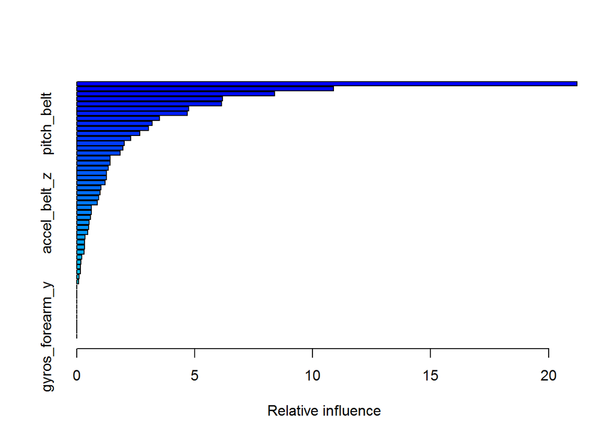

```
##                                 var rel.inf
## roll_belt                 roll_belt  21.207
## pitch_forearm         pitch_forearm  10.879
## yaw_belt                   yaw_belt   8.388
## magnet_dumbbell_y magnet_dumbbell_y   6.171
## magnet_dumbbell_z magnet_dumbbell_z   6.138
```

```r
## Top 5 Influencers
head(summary(fit),5)
```